# Model Selection

Statistics

Model Selection

Published

July 16, 2019

# 1 Visualizing data (Chen, O’Leary, and Evans 2019)

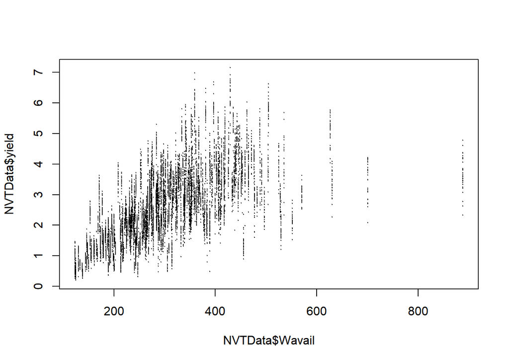

```r
NVTData <- read.table("NVTData.txt",header = TRUE)
plot(NVTData$Wavail,NVTData$yield,cex=0.1)
```

# 2 Fitting data

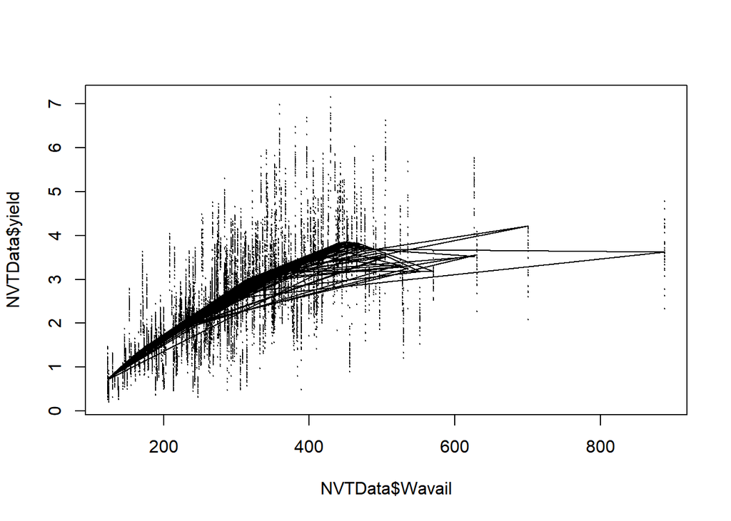

```r
fitgam0 <- gam(yield ~ s(Wavail), data=NVTData)
plot(NVTData$Wavail,NVTData$yield,cex=0.1)
points(NVTData$Wavail,fitgam0$fitted.values,type="l")
```

# 3 Ordering data

```r
datOR    <- NVTData[order(NVTData$Wavail),]
knotsNum <- length(table(datOR$Wavail)) # unique knots
print(knotsNum)
```

```
## [1] 362
```

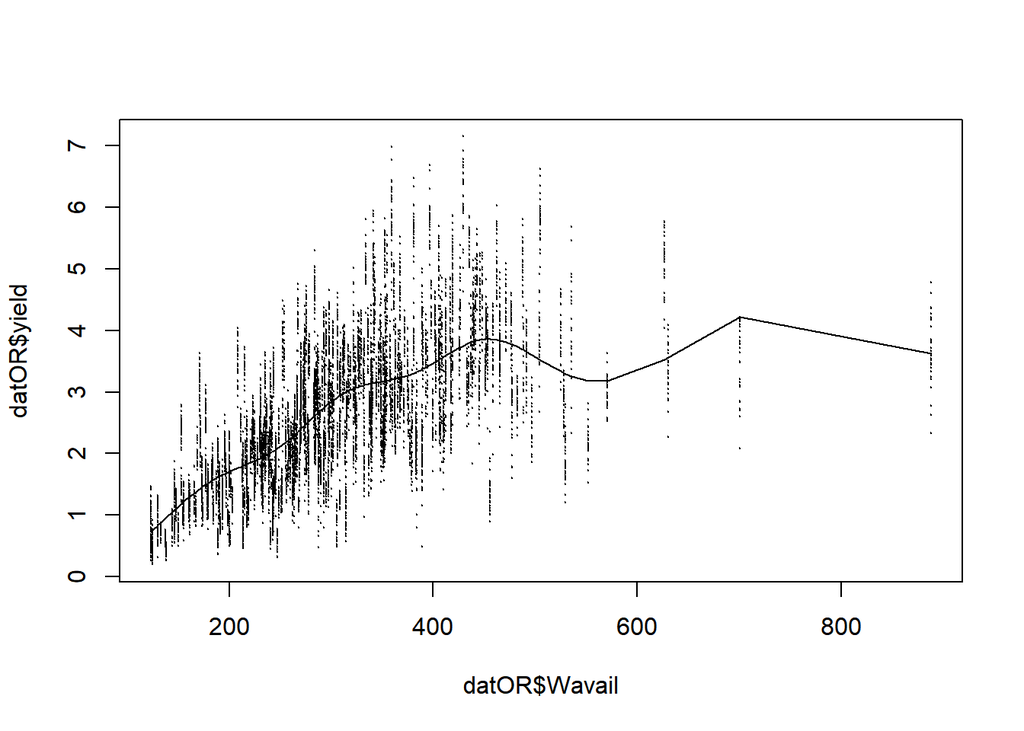

```r
fitgam1 <- gam(yield ~ s(Wavail), data=datOR)
plot(datOR$Wavail,datOR$yield,cex=0.1)
points(datOR$Wavail,fitgam1$fitted.values,type="l")
```

# 4 Comparison

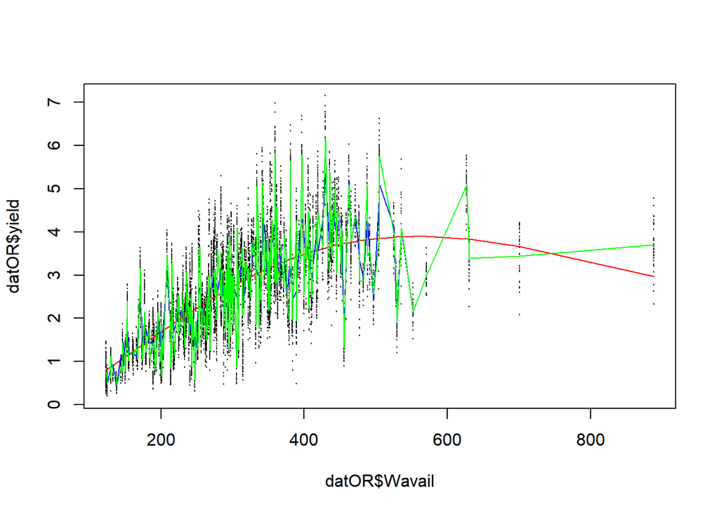

```r
fitgam2 <- gam(yield ~ s(Wavail,k=3),   data = datOR)
fitgam3 <- gam(yield ~ s(Wavail,k=100), data = datOR)
fitgam4 <- gam(yield ~ s(Wavail,k=300), data = datOR)
plot(datOR$Wavail,datOR$yield,cex=0.1)
points(datOR$Wavail,fitgam2$fitted.values,type="l",col="red")
points(datOR$Wavail,fitgam3$fitted.values,type="l",col="blue")
points(datOR$Wavail,fitgam4$fitted.values,type="l",col="green")
```

```r
compTable <- AIC(fitgam0,fitgam1,fitgam2,fitgam3,fitgam4)
compTable$BIC <- BIC(fitgam0,fitgam1,fitgam2,fitgam3,fitgam4)$BIC
compTable$GCV <- c(fitgam0$gcv.ubre, fitgam1$gcv.ubre, fitgam2$gcv.ubre, fitgam3$gcv.ubre, fitgam4$gcv.ubre)
compTable$deviance <- c(fitgam0$deviance, fitgam1$deviance, fitgam2$deviance, fitgam3$deviance, fitgam4$deviance)
compTable$RMSE<- c(sqrt(mean((fitgam0$fitted.values-NVTData$yield)^2)), sqrt(mean((fitgam1$fitted.values-datOR$yield)^2)), sqrt(mean((fitgam2$fitted.values-datOR$yield)^2)), sqrt(mean((fitgam3$fitted.values-datOR$yield)^2)), sqrt(mean((fitgam4$fitted.values-datOR$yield)^2)))

print(compTable)
```

```
##                 df      AIC      BIC       GCV deviance      RMSE
## fitgam0  10.933138 30492.71 30573.87 0.6877164 8498.209 0.8286211
## fitgam1  10.933138 30492.71 30573.87 0.6877164 8498.209 0.8286211
## fitgam2   3.998908 30748.05 30777.73 0.7020508 8685.073 0.8376817
## fitgam3 100.266214 26895.97 27640.31 0.5143182 6264.017 0.7114080
## fitgam4 300.368361 14930.74 17160.55 0.1957113 2306.556 0.4316923
```

From the criteria, such as AIC, GCV, deviance and root mean squared error (RMSE), they indicate that the more knots are used in the model, the better it should be.

```r
for(kts in 3:knotsNum){
  for(st in 1:5){  # 5-fold cross-validation
    s         <- seq(st,dim(dat3)[1],by=5)

    tempTrain <- datOR[-s,]
    tempTests <- datOR[s,]

    fitgam <- gam(yield ~ s(Wavail,k=kts), data=tempTrain)

    cv.train[kts,st] <- mean((fitgam$fitted.values-tempTrain$yield)^2)

    preTest <- predict(fitgam,data.frame(Wavail = tempTests$Wavail))

    cv.tests[kts,st] <- mean((preTest-tempTests$yield)^2)
  }
}
```

```r
# aics   <- numeric(knotsNum)
# gcvs   <- numeric(knotsNum)
# mses   <- numeric(knotsNum)
for(kts in 3:knotsNum){
  fitgam    <- gam(yield ~ s(Wavail,k=kts), data=dat3)
  aics[kts] <- fitgam$aic
  gcvs[kts] <- fitgam$gcv.ubre
  mses[kts] <- sqrt(mean((fitgam$fitted.values-dat3$yield)^2))
}
```

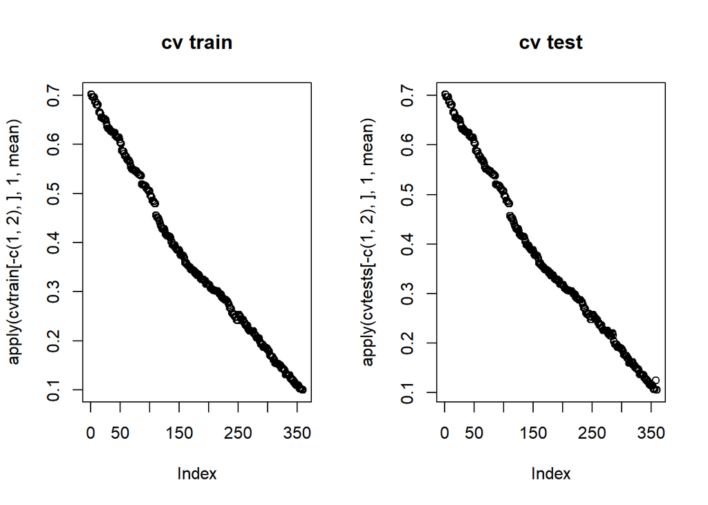

```r
cvtrain <- read.table("cvtrain.txt",header = TRUE)
cvtests <- read.table("cvtests.txt",header = TRUE)
par(mfrow=c(1,2));
plot(apply(cvtrain[-c(1,2),],1,mean),main="cv train");
plot(apply(cvtests[-c(1,2),],1,mean),main="cv test");
```

```r
par(mfrow=c(1,1))
```

In the package `mgcv`, the spline method `s()` of the function `gam()` is the default penalized thin plate regression spline, which tends to give the best MSE performance (Wood 2003, 2006).

Zhu, Li, and Liang (2009) conclude that:

1. $R^2$ and $RMSE$ have the same properties and perform worst in their simulation.
2. The sample size has an effect on the performance $AIC$, $AIC_c$ and $BIC$.
3. $AIC$ is not suitable to use in small samples and tends to select more complex model when the sample size becomes large.
4. $AIC_c$ and $BIC$ have best performance in small and large sample cases, respectively.

Here is the contradiction:

The optimal model, which is found by either `AIC()`, `BIC()`, etc., is not the best we want (by visualization).

# 5 Potential solutions

## 5.1 Aggregating data

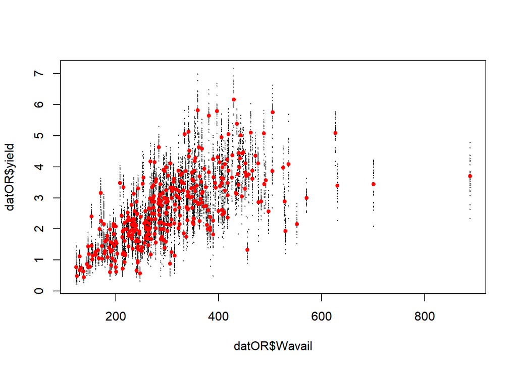

```r
datOR.agg <- aggregate(datOR[c("lat","longi","Wavail","yield")],list(datOR$Wavail),mean)

plot(datOR$Wavail,datOR$yield,cex=0.1,pch=20)
points(datOR.agg$Wavail,datOR.agg$yield,pch=20,col="red")
```

```r
# aics.agg <- numeric(knotsNum)
# gcvs.agg <- numeric(knotsNum)
# divs.agg <- numeric(knotsNum)
# mses.agg <- numeric(knotsNum)
for(kts in 3:knotsNum){
  fitgam.agg    <- gam(yield ~ s(Wavail,k=kts), data=datOR.agg)
  aics.agg[kts] <- fitgam.agg$aic
  gcvs.agg[kts] <- fitgam.agg$gcv.ubre
  divs.agg[kts] <- fitgam.agg$deviance
  mses.agg[kts] <- sqrt(mean((fitgam.agg$fitted.values-datOR.agg$yield)^2))
}
```

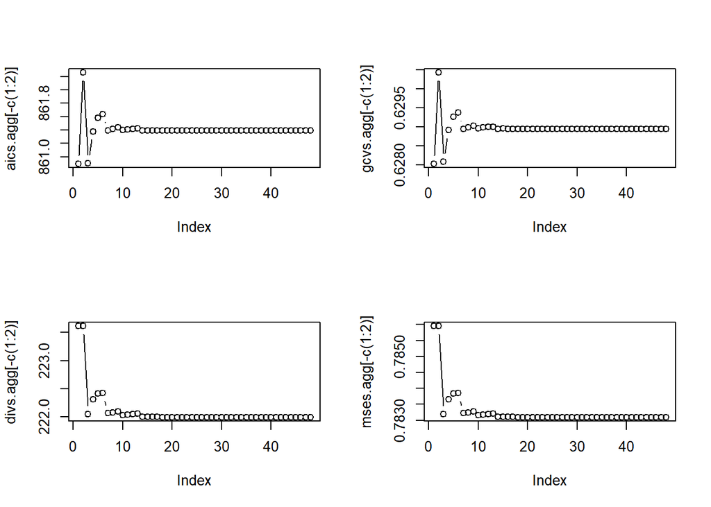

```r
par(mfrow=c(2,2))
plot(aics.agg[-c(1:2)],type="b")
plot(gcvs.agg[-c(1:2)],type="b")
plot(divs.agg[-c(1:2)],type="b")
plot(mses.agg[-c(1:2)],type="b")
```

```r
par(mfrow=c(1,1))
```

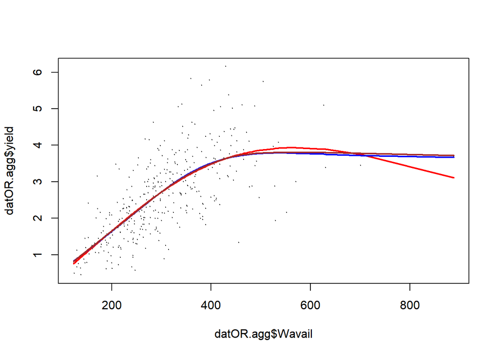

```r
fitgam.agg1 <- gam(yield ~ s(Wavail,k=3), data=datOR.agg)
fitgam.agg2 <- gam(yield ~ s(Wavail,k=5), data=datOR.agg)
fitgam.agg3 <- gam(yield ~ s(Wavail,k=100), data=datOR.agg)
fitgam.agg4 <- gam(yield ~ s(Wavail,k=300), data=datOR.agg)

plot(datOR.agg$Wavail,datOR.agg$yield,cex=0.1,pch=20)
points(datOR.agg$Wavail,fitgam.agg1$fitted.values,type="l",col="red",lwd=2)
points(datOR.agg$Wavail,fitgam.agg2$fitted.values,type = "l",col="blue",lwd=2)
points(datOR.agg$Wavail,fitgam.agg3$fitted.values,type = "l",col="green",lwd=2)
points(datOR.agg$Wavail,fitgam.agg4$fitted.values,type = "l",col="brown",lwd=2)
```

```r
compTable.agg <- AIC(fitgam.agg1,fitgam.agg2,fitgam.agg3,fitgam.agg4)
compTable.agg$BIC <- BIC(fitgam.agg1,fitgam.agg2,fitgam.agg3,fitgam.agg4)$BIC
compTable.agg$GCV <- c(fitgam.agg1$gcv.ubre, fitgam.agg2$gcv.ubre, fitgam.agg3$gcv.ubre, fitgam.agg4$gcv.ubre)
compTable.agg$deviance <- c(fitgam.agg1$deviance, fitgam.agg2$deviance, fitgam.agg3$deviance, fitgam.agg4$deviance)
compTable.agg$RMSE<- c(sqrt(mean((fitgam.agg1$fitted.values-datOR.agg$yield)^2)), sqrt(mean((fitgam.agg2$fitted.values-datOR.agg$yield)^2)), sqrt(mean((fitgam.agg3$fitted.values-datOR.agg$yield)^2)), sqrt(mean((fitgam.agg4$fitted.values-datOR.agg$yield)^2)))
print(compTable.agg)
```

```
##                   df      AIC      BIC       GCV deviance      RMSE
## fitgam.agg1 3.981404 860.8931 876.3873 0.6280246 223.6155 0.7859532
## fitgam.agg2 5.259226 860.9008 881.3679 0.6280828 222.0472 0.7831921
## fitgam.agg3 5.549870 861.3912 882.9893 0.6289465 221.9914 0.7830937
## fitgam.agg4 5.549814 861.3912 882.9891 0.6289465 221.9914 0.7830939
```

Drawbacks: some valuable data are missing; aggregated by `mean()` might not be the best option.

## 5.2 Weighted values

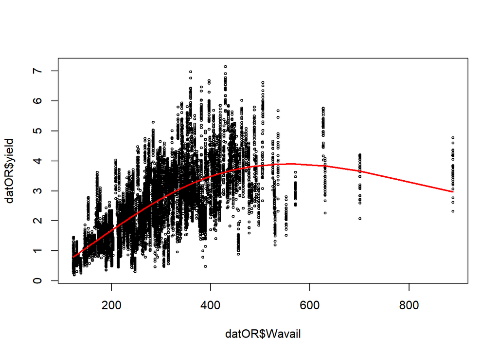

```r
datOR.wts <- datOR
plot(datOR$Wavail,datOR$yield,cex=0.5)
points(datOR$Wavail,fitgam2$fitted.values,type="l",col="red",lwd=2)
```

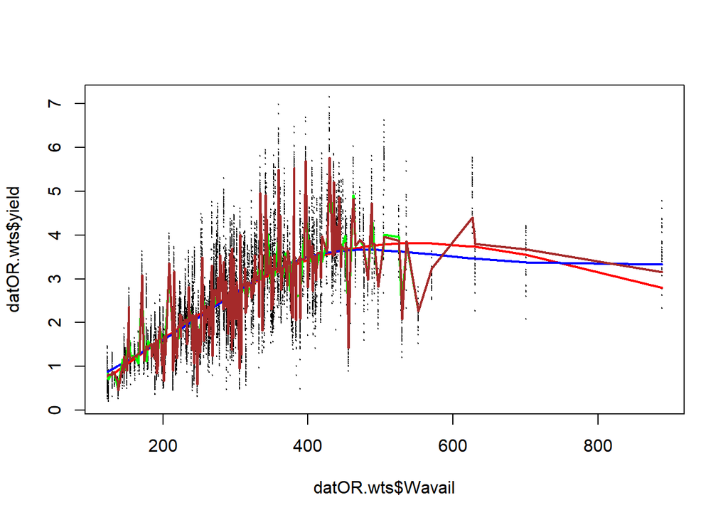

```r
sres0<-(datOR$yield - fitgam2$fitted.values)^2
sres <- 1/sres0
datOR.wts$Weights <- 0
wavs <- names(table(datOR.wts$Wavail))

for(k in wavs){
  wh <- which(datOR.wts$Wavail == k)
  datOR.wts$Weights[wh] <- sres[wh]/sum(sres[wh])
}

fitgam.wts1 <- gam(yield ~ s(Wavail,k=3),weights = datOR.wts$Weights, data=datOR.wts)
fitgam.wts2 <- gam(yield ~ s(Wavail,k=5),weights = datOR.wts$Weights, data=datOR.wts)
fitgam.wts3 <- gam(yield ~ s(Wavail,k=100),weights = datOR.wts$Weights, data=datOR.wts)
fitgam.wts4 <- gam(yield ~ s(Wavail,k=300),weights = datOR.wts$Weights, data=datOR.wts)

plot(datOR.wts$Wavail,datOR.wts$yield,cex=0.1,pch=20)
points(datOR.wts$Wavail,fitgam.wts1$fitted.values,type = "l",col="red",lwd=2)
points(datOR.wts$Wavail,fitgam.wts2$fitted.values,type = "l",col="blue",lwd=2)
points(datOR.wts$Wavail,fitgam.wts3$fitted.values,type = "l",col="green",lwd=2)
points(datOR.wts$Wavail,fitgam.wts4$fitted.values,type = "l",col="brown",lwd=2)
```

```r
AIC(fitgam.wts1,fitgam.wts2,fitgam.wts3,fitgam.wts4)
```

```
##                     df      AIC
## fitgam.wts1   3.999472 49964.63
## fitgam.wts2   5.995467 49841.01
## fitgam.wts3 100.426600 45655.24
## fitgam.wts4 300.412109 31041.80
```

```r
BIC(fitgam.wts1,fitgam.wts2,fitgam.wts3,fitgam.wts4)
```

```
##                     df      BIC
## fitgam.wts1   3.999472 49994.32
## fitgam.wts2   5.995467 49885.51
## fitgam.wts3 100.426600 46400.77
## fitgam.wts4 300.412109 33271.94
```

## 5.3 Taking a subset

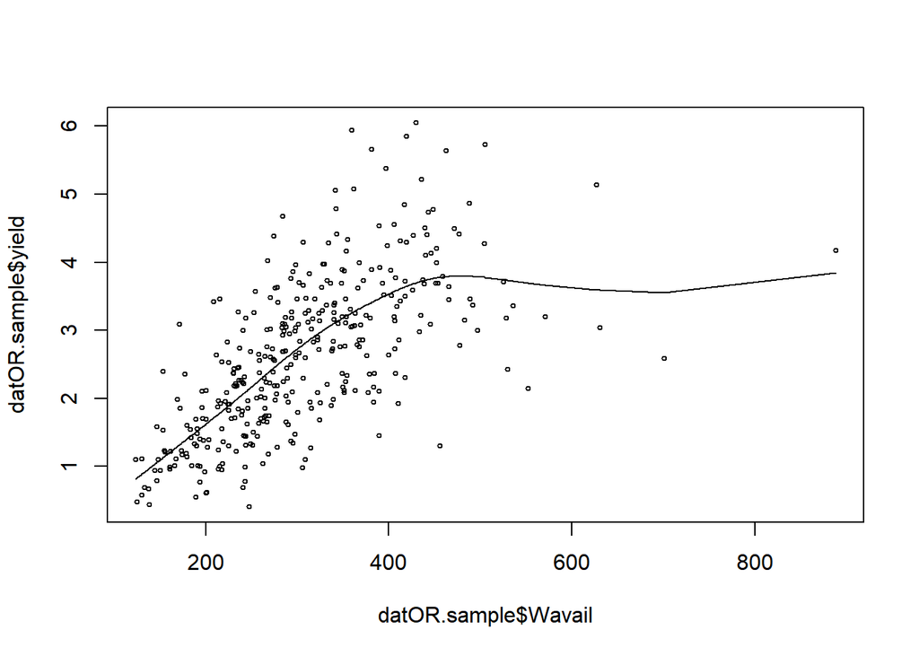

```r
set.seed(2019)
datOR.sample <- NULL
for(k in wavs){
  tempdat<- datOR[which(datOR$Wavail == k),]
  s<- sort(sample(1:nrow(tempdat),1))
  datOR.sample<-rbind(datOR.sample,tempdat[s,])
}

fitgam.sample <- gam(yield  ~ s(Wavail,k=300), data=datOR.sample)
plot(datOR.sample$Wavail,datOR.sample$yield,cex=0.5)
points(datOR.sample$Wavail,fitgam.sample$fitted.values,type = "l")
```

```r
AIC(fitgam.sample)
```

```
## [1] 884.1104
```

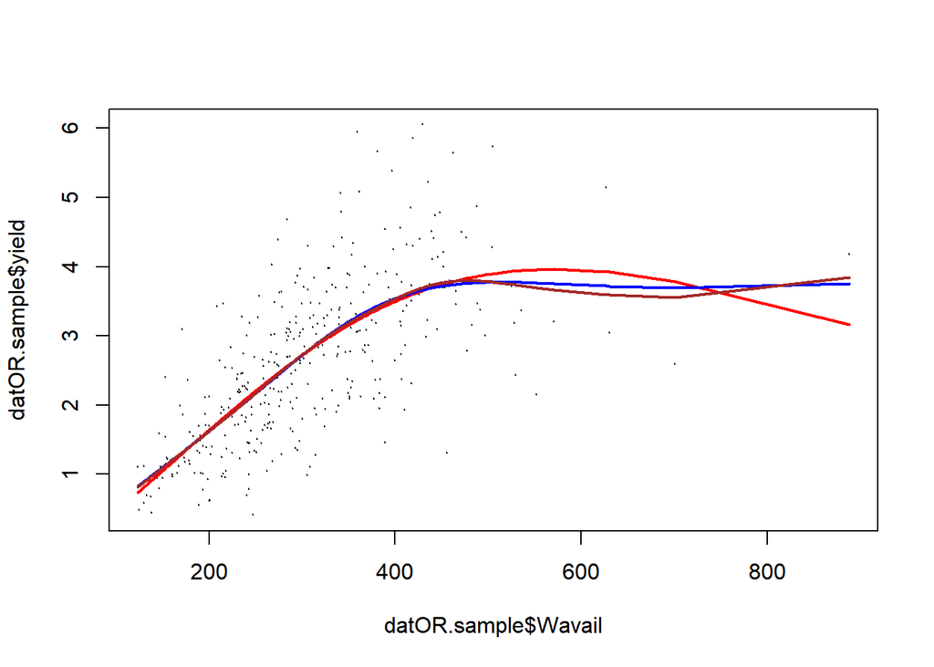

```r
fitgam.sample1 <- gam(yield ~ s(Wavail,k=3), data=datOR.sample)
fitgam.sample2 <- gam(yield ~ s(Wavail,k=5), data=datOR.sample)
fitgam.sample3 <- gam(yield ~ s(Wavail,k=100), data=datOR.sample)
fitgam.sample4 <- gam(yield ~ s(Wavail,k=300), data=datOR.sample)

plot(datOR.sample$Wavail,datOR.sample$yield,cex=0.1,pch=20)
points(datOR.sample$Wavail,fitgam.sample1$fitted.values,type = "l",col="red",lwd=2)
points(datOR.sample$Wavail,fitgam.sample2$fitted.values,type = "l",col="blue",lwd=2)
points(datOR.sample$Wavail,fitgam.sample3$fitted.values,type = "l",col="green",lwd=2)
points(datOR.sample$Wavail,fitgam.sample4$fitted.values,type = "l",col="brown",lwd=2)
```

```r
AIC(fitgam.sample1,fitgam.sample2,fitgam.sample3,fitgam.sample4)
```

```
##                      df      AIC
## fitgam.sample1 3.980366 884.9641
## fitgam.sample2 5.404610 884.2511
## fitgam.sample3 6.515357 884.1104
## fitgam.sample4 6.515493 884.1104
```

```r
BIC(fitgam.sample1,fitgam.sample2,fitgam.sample3,fitgam.sample4)
```

```
##                      df      BIC
## fitgam.sample1 3.980366 900.4543
## fitgam.sample2 5.404610 905.2840
## fitgam.sample3 6.515357 909.4659
## fitgam.sample4 6.515493 909.4664
```

### 5.3.1 A naive resampling approach

```r
N <- 30
boost.max1 <- matrix(0,N,362)
boost.max2 <- matrix(0,N,362)
boost.max3 <- matrix(0,N,362)
boost.max4 <- matrix(0,N,362)
for(i in 1:N){
  datOR.boost <- NULL
  for(k in wavs){
    tempdat<- datOR[which(datOR$Wavail == k),]
    s<- sort(sample(1:nrow(tempdat),1))
    datOR.boost <- rbind(datOR.boost,tempdat[s,])
  }
  fitgam.boost1 <- gam(yield ~ s(Wavail,k=3),   data=datOR.boost)
  fitgam.boost2 <- gam(yield ~ s(Wavail,k=5),   data=datOR.boost)
  fitgam.boost3 <- gam(yield ~ s(Wavail,k=100), data=datOR.boost)
  fitgam.boost4 <- gam(yield ~ s(Wavail,k=300), data=datOR.boost)

  boost.max1[i,] <- fitgam.boost1$fitted.values
  boost.max2[i,] <- fitgam.boost2$fitted.values
  boost.max3[i,] <- fitgam.boost3$fitted.values
  boost.max4[i,] <- fitgam.boost4$fitted.values
  cat(i);
}
```

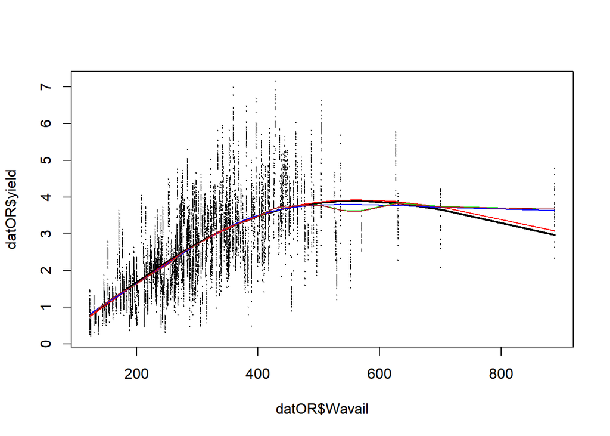

[figure not shown]

[figure not shown]

[figure not shown]

[figure not shown]

```r
plot(datOR$Wavail,datOR$yield,cex=0.1)
points(datOR$Wavail,fitgam2$fitted.values,type="l",lwd=2)
points(datOR.sample$Wavail,apply(boost.max1,2,mean),type="l",col="red")
points(datOR.sample$Wavail,apply(boost.max2,2,mean),type="l",col="blue")
points(datOR.sample$Wavail,apply(boost.max3,2,mean),type="l",col="green")
points(datOR.sample$Wavail,apply(boost.max4,2,mean),type="l",col="brown")
```

# 6 A question

Is it worth spending some time on finding an approach, which leads to the consistency: the optimal is the best, for large size longitudinal data?

# References

Chen, Kefei, Rebecca A. O’Leary, and Fiona H. Evans. 2019. “A Simple and Parsimonious Generalised Additive Model for Predicting Wheat Yield in a Decision Support Tool.” *Agricultural Systems* 173: 140–50.

Wood, Simon N. 2003. “Thin Plate Regression Splines.” *Journal of the Royal Statistical Society: Series B (Statistical Methodology)* 65 (1): 95–114.

Wood, S. N. 2006. “Generalized Additive Models: An Introduction with R.”

Zhu, Lixin, Lifang Li, and Zhenlin Liang. 2009. “Comparison of Six Statistical Approaches in the Selection of Appropriate Fish Growth Models.” *Chinese Journal of Oceanology and Limnology* 27 (3): 457. https://doi.org/10.1007/s00343-009-9236-6.